# EAE

### Chr 18

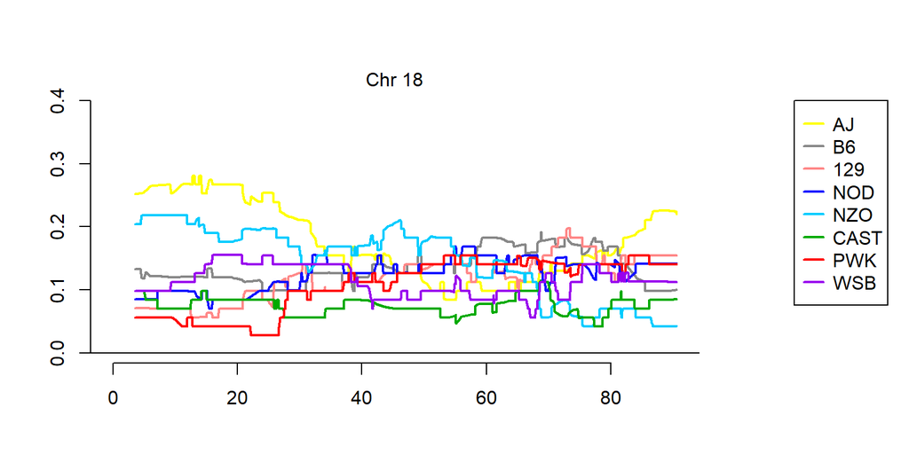

### Chr 19

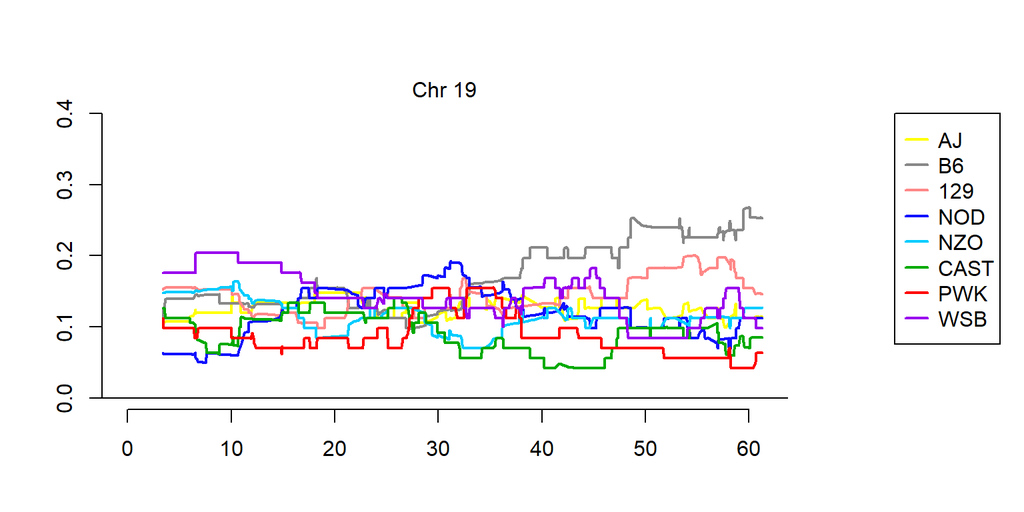

### Chr X

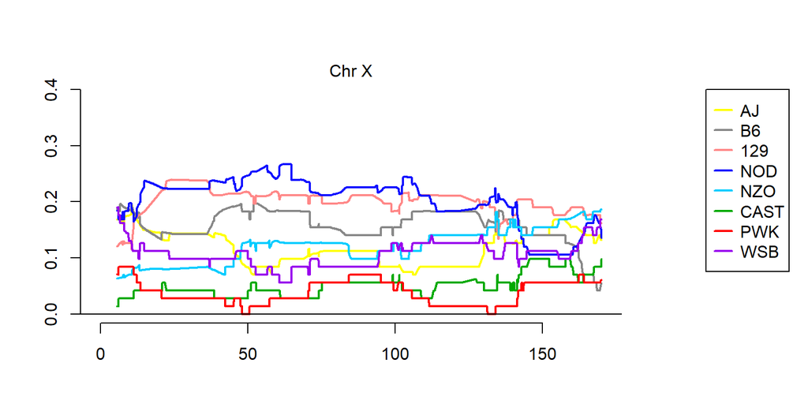

## Sex Effects Plotted by Individual

The following plots show the trait distributions for each strain. Each plot is ordered by overall strain mean.

For each strain, the dots are split and colored by sex. Each point represents one mouse. The horizontal line shows the mean value for that sex. This helps show where there might be sex effects in individual strains.

```r
#This function puts the given trait into a list based
#on strain and plots it if desired.
trait_list <- function(strain.tables, trait.name, exclude.zeros = TRUE,
    col.by = NULL, plot.results = TRUE){

    if(length(col.by) == 0){col.by = rep("gray", sum(sapply(strain.tables, nrow)))}
    if(length(col.by) == 1){col.by = rep(col.by, sum(sapply(strain.tables, nrow)))}
    u_cols <- unique(col.by)

    if(length(u_cols) > 1){
        col.seg <- segment.region(-0.15, 0.15, length(u_cols), "ends")
    }else{
        col.seg <- 0
    }

    strain.trait <- lapply(strain.tables, function(x) x[,trait.name])
    names(strain.trait) <- names(strain.tables)

    if(exclude.zeros){
        #remove 0, to do CDS only
        nonzero.idx <- which(unlist(strain.trait) != 0) #find indices to remove from other variables
        strain.trait <- lapply(strain.trait, function(x) x[which(x != 0)]) #remove zeros
    }else{
        nonzero.idx <- 1:length(unlist(strain.trait))
    }
    col.by <- col.by[nonzero.idx]

    trait.mean <- sapply(strain.trait, mean)
    trait.order <- order(trait.mean)

    plot.idx <- unlist(lapply(1:length(strain.trait), function(x) rep(x, length(strain.trait[[x]]))))

    if(plot.results){
        ymin <- min(unlist(strain.trait), na.rm = TRUE)
        ymax <- max(unlist(strain.trait), na.rm = TRUE)

        plot.new()
        plot.window(xlim = c(1,length(strain.tables)), ylim = c(ymin, ymax))
        x <- 1
        for(i in trait.order){
            #plot the colors separately so we can see them better
            for(j in 1:length(u_cols)){
                ind.idx <- which(plot.idx == i)
                col.idx <- which(col.by[ind.idx] == u_cols[j])
                points(rep(x+col.seg[j], length(col.idx)),
                    strain.trait[[i]][col.idx], col = u_cols[j], pch = 16)
                points(x+col.seg[j],
                    mean(strain.trait[[i]][col.idx]), col = u_cols[j], pch = "-", cex = 2)
                #segments(x0 = x+col.seg[j], y0 = ymin, y1 = ymax, col = u_cols[j])
                segments(x0 = x+0.5, y0 = ymin, y1 = ymax, col = "gray")
            }
            x <- x + 1
        }
        axis(2)
        par(xpd = TRUE)
        text(x = 1:length(strain.trait), y = rep(ymin, length(strain.trait)),
            labels = names(strain.trait)[trait.order], srt = 90, adj = 1)
        par(xpd = FALSE)
        mtext(trait.name, side = 3, line = 2, font = 2)
        #stripchart(strain.trait[trait.order], vertical = TRUE, pch = 16, method = "jitter", las = 2, main = trait.name, ylab = trait.name)
    }
    return(strain.trait)
}

#This function plots the mean by the col.by argument
#and tests for statistical differences between these
#means. It returns a vector of p values, one for each
#strain.
trait_bars <- function(strain.tables, trait.name, exclude.zeros = TRUE,
    col.by = NULL, plot.results = TRUE){

    if(length(col.by) == 0){col.by = rep("gray", sum(sapply(strain.tables, nrow)))}
    if(length(col.by) == 1){col.by = rep(col.by, sum(sapply(strain.tables, nrow)))}
    u_cols <- unique(col.by)
    col.seg <- segment.region(-0.15, 0.15, length(u_cols), "ends")

    strain.trait <- lapply(strain.tables, function(x) x[,trait.name])
    names(strain.trait) <- names(strain.tables)

    if(exclude.zeros){
        #remove 0, to do CDS only
        nonzero.idx <- which(unlist(strain.trait) != 0) #find indices to remove from other variables
        strain.trait <- lapply(strain.trait, function(x) x[which(x != 0)]) #remove zeros
    }else{
        nonzero.idx <- 1:length(unlist(strain.trait))
    }
    col.by <- col.by[nonzero.idx]

    trait.mean <- sapply(strain.trait, mean)
    trait.order <- order(trait.mean)

    plot.idx <- unlist(lapply(1:length(strain.trait), function(x) rep(x, length(strain.trait[[x]]))))
    diff.p <- rep(NA, length(strain.tables))
    names(diff.p) <- names(strain.tables)[trait.order]

    if(plot.results){
        ymin <- min(unlist(strain.trait), na.rm = TRUE)
        ymax <- max(unlist(strain.trait), na.rm = TRUE)

        plot.new()
        plot.window(xlim = c(1,length(strain.tables)), ylim = c(ymin, ymax))
        x <- 1
        for(i in trait.order){
            #plot the colors separately so we can see them better
            test.diff <- vector(mode = "list", length = length(u_cols))
            for(j in 1:length(u_cols)){
                ind.idx <- which(plot.idx == i)
                col.idx <- which(col.by[ind.idx] == u_cols[j])
                points(x+col.seg[j],
                    mean(strain.trait[[i]][col.idx]), col = u_cols[j], type = "h",
                    lwd = 3)
                test.diff[[j]] <- strain.trait[[i]][col.idx]
                #segments(x0 = x+col.seg[j], y0 = ymin, y1 = ymax, col = u_cols[j])
                segments(x0 = x+0.5, y0 = ymin, y1 = ymax, col = "gray")
            }
            if(all(sapply(test.diff, length) > 1)){
                test <- aov.by.list(test.diff)
                diff.p[x] <- test[1,"Pr(>F)"]
            }
            x <- x + 1
        }
        axis(2)
        par(xpd = TRUE)
        text(x = 1:length(strain.trait), y = rep(ymin, length(strain.trait)),
            labels = names(strain.trait)[trait.order], srt = 90, adj = 1)
        par(xpd = FALSE)
        mtext(trait.name, side = 3, line = 2, font = 2)
        abline(h = 0)
        #stripchart(strain.trait[trait.order], vertical = TRUE, pch = 16, method = "jitter", las = 2, main = trait.name, ylab = trait.name)
    }
    return(diff.p)
}
```

```r
strain.tables <- lapply(mapping.strains, function(x) norm.cds[which(cds[,1] == x),])
strain.factors <- lapply(mapping.strains, function(x) factor.cds[which(cds[,1] == x),])
names(strain.tables) <- names(strain.factors) <- mapping.strains
```

### Classical

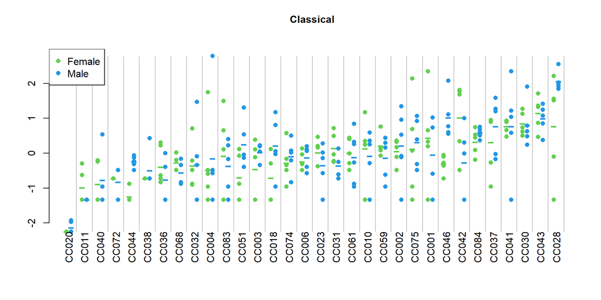

```r
sex.col <- as.numeric(as.factor(unlist(lapply(strain.factors, function(x) x[,"Sex"]))))

strain.classical <- trait_list(strain.tables, "Classical", col.by = sex.col+2,
    exclude.zeros = exclude.zeros)
legend("topleft", pch = 16, col = unique(sex.col)+2, legend = c("Female", "Male"),
    bg = "white")
```

### AR

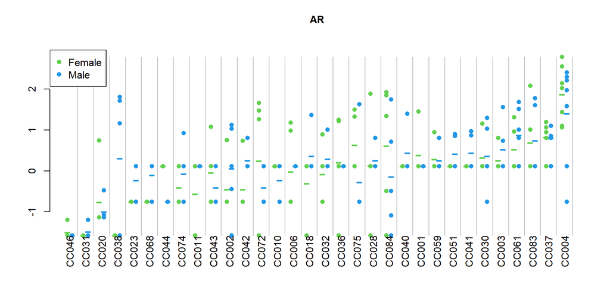

```r
strain.ar  <- trait_list(strain.tables, "AR", col.by = sex.col+2,
    exclude.zeros = exclude.zeros)
legend("topleft", pch = 16, col = unique(sex.col)+2, legend = c("Female", "Male"),
    bg = "white")
```

### Global

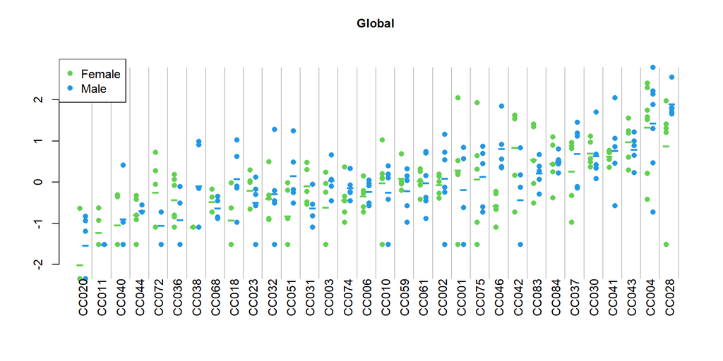

```r
strain.global <- trait_list(strain.tables, "Global",col.by = sex.col+2,
    exclude.zeros = exclude.zeros)
legend("topleft", pch = 16, col = unique(sex.col)+2, legend = c("Female", "Male"),
    bg = "white")
```

### Average Weight Loss

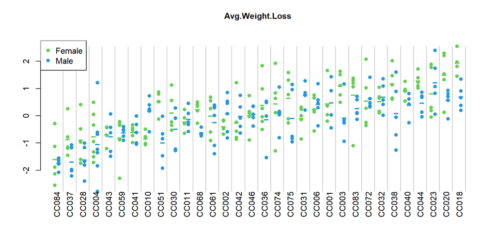

```r
strain.global <- trait_list(strain.tables, "Avg.Weight.Loss",col.by = sex.col+2,
    exclude.zeros = exclude.zeros)
legend("topleft", pch = 16, col = unique(sex.col)+2, legend = c("Female", "Male"),
    bg = "white")
```

## Sex Effects by Strain

The following plots distill the above figures to just the means for each sex. This makes it easier to see where the means for the two sexes are different.

An imbalance of sex effects in the different strains could lead to strange mapping patterns (I think).

The top plot for each shows the means for each sex and each strain. The strains are ordered by overall strain mean.

The middle plot shows the -log10 of the p value for each difference. The solid line shows the p = 0.05 threshold, and the dashed line shows the bon ferroni adjust p value threshold.

The bottom dot plot shows a direct comparison of female means vs. male means for each strain and each trait. Strains with a large difference between male and female (90th percentile) are labeled.

### Classical

```r
plot_bars <- function(trait.name, exclude.zeros){
    layout(matrix(c(1,2), ncol = 1), heights = c(1, 0.5))
    par(mar = c(4,4,4,4))
    classical.p <- trait_bars(strain.tables, trait.name, col.by = sex.col+2,
        exclude.zeros = exclude.zeros)
    legend("topleft", pch = 16, col = unique(sex.col)+2, legend = c("Female", "Male"),
        bg = "white")
    par(mar = c(4,3.5,0,3.5))
    p.thresh <- c(-log10(0.05), -log10(0.05/length(strain.tables)))
    ymax <- max(c(p.thresh, -log10(classical.p)), na.rm = TRUE)
    ymax <- ceiling(ymax*1)/1
    a <- barplot(-log10(classical.p), las = 2, ylim = c(0, ymax))
    mtext("-log10(p) for sex difference", side = 2, line = 2.5)
    segments(x0 = rep(0, length(p.thresh)), x1 = rep(max(a[,1]), length(p.thresh)),
        y0 = p.thresh, lty = c(1,2))
    par(xpd = TRUE)
    text(x = max(a[,1]), y = -log10(0.05), labels = "0.05", adj = 0)
    text(x = max(a[,1]), y = -log10(0.05/length(strain.tables)), labels = "corrected", adj = 0)
    par(xpd = FALSE)
}
```

```r
plot_dots <- function(trait.name, diff.percentile = 90){

    f.vals <- lapply(1:length(strain.factors), function(x) strain.tables[[x]][which(strain.factors[[x]][,"Sex"] == "F"),trait.name])
    m.vals <- lapply(1:length(strain.factors), function(x) strain.tables[[x]][which(strain.factors[[x]][,"Sex"] == "M"),trait.name])

    f.means <- sapply(f.vals, mean)
    m.means <- sapply(m.vals, mean)

    diffs <- abs(f.means - m.means)
    diff.thresh <- get.percentile(diffs, diff.percentile)
    big.diffs <- which(diffs >= diff.thresh)

    plot(f.means, m.means, pch = 16, xlab = "Female Mean", ylab = "Male Mean",
    main = trait.name)
    abline(0,1)
    text(f.means[big.diffs], m.means[big.diffs], labels = names(strain.factors)[big.diffs],
        pos = 2)

}
```

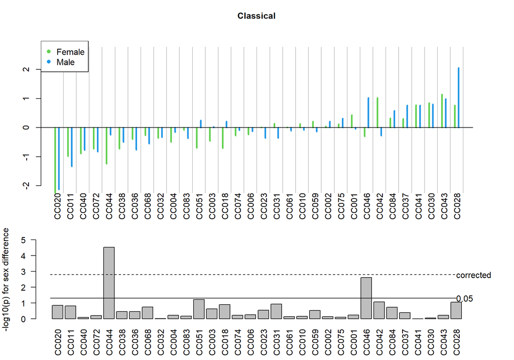

```r
plot_bars("Classical", exclude.zeros = exclude.zeros)
```

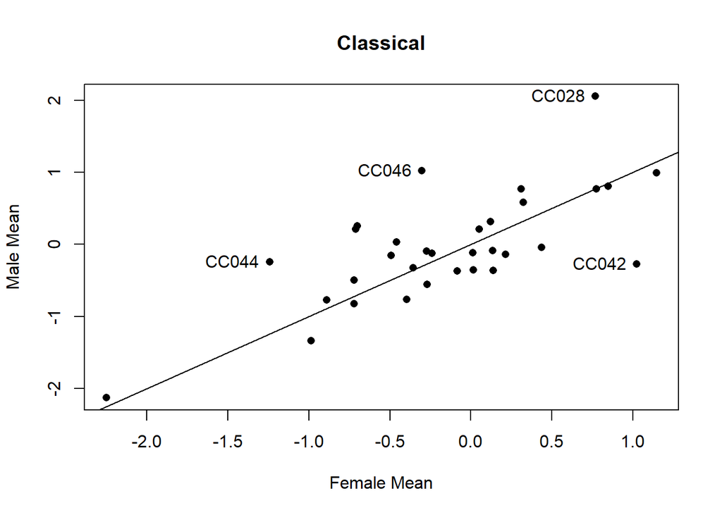

```r
plot_dots("Classical")
```

### AR

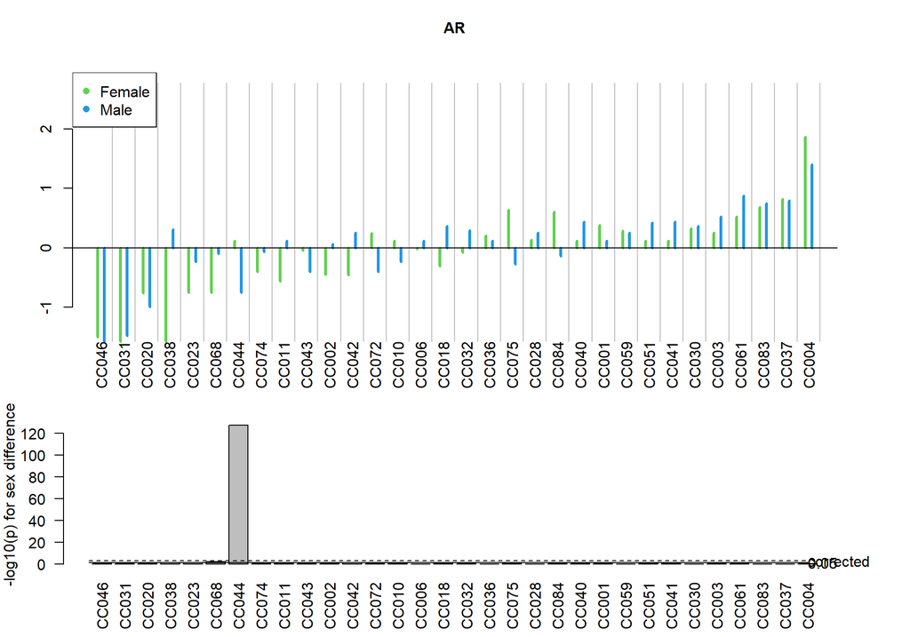

```r
plot_bars("AR", exclude.zeros = exclude.zeros)
```

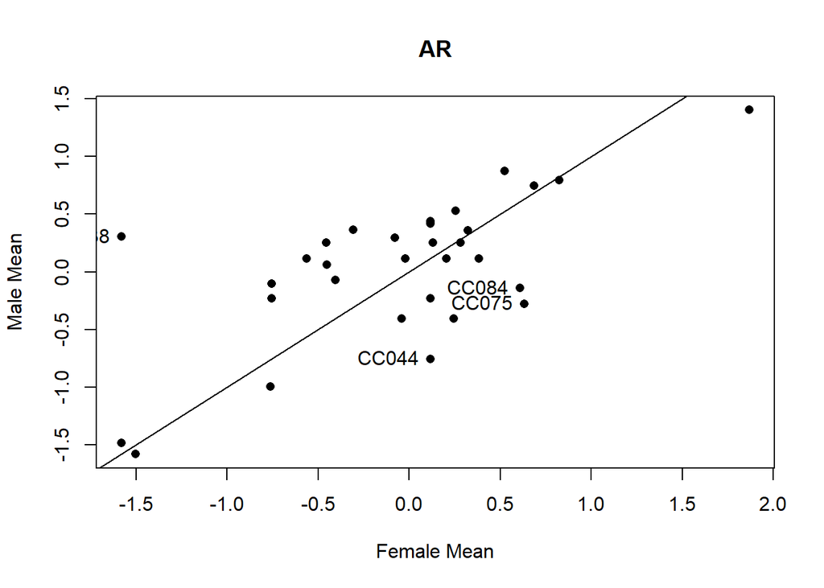

```r
plot_dots("AR")
```

### Global

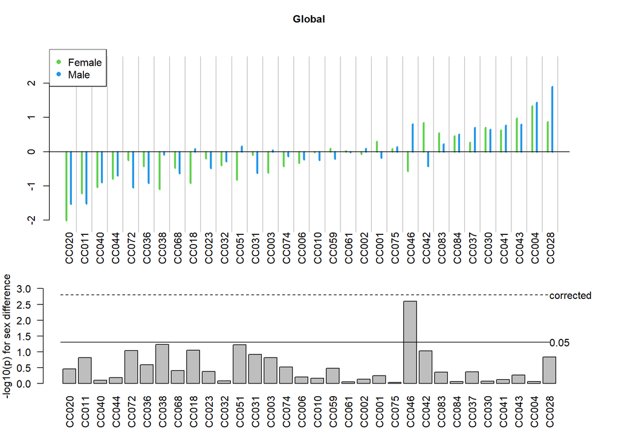

```r
plot_bars("Global", exclude.zeros = exclude.zeros)
```

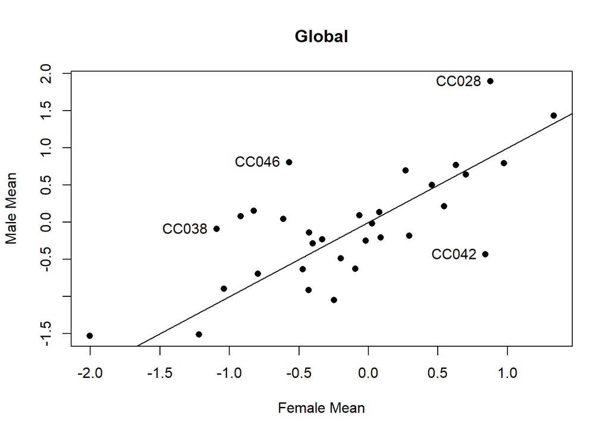

```r
plot_dots("Global")
```

### Average Weight Loss

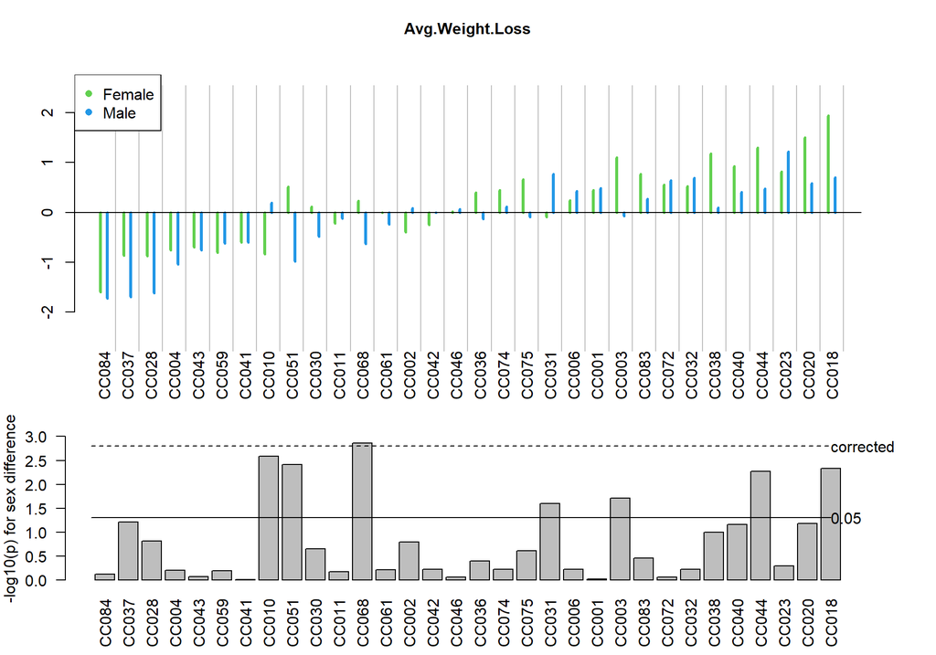

```r
plot_bars("Avg.Weight.Loss", exclude.zeros = exclude.zeros)
```

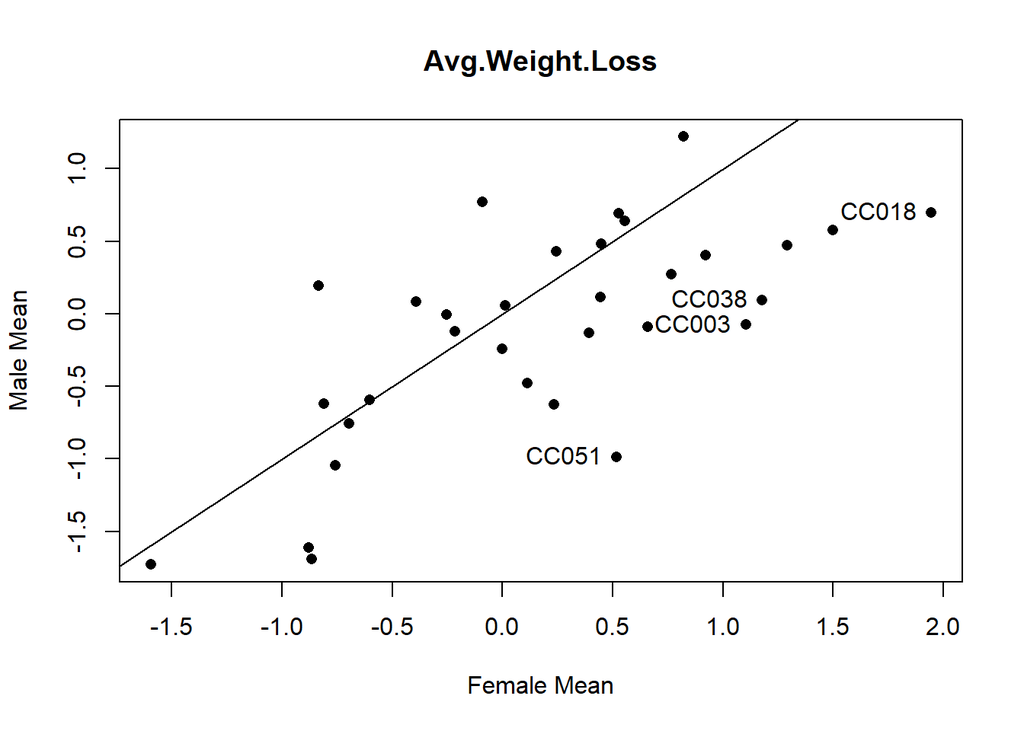

```r
plot_dots("Avg.Weight.Loss")
```

### Overall Sex Effect

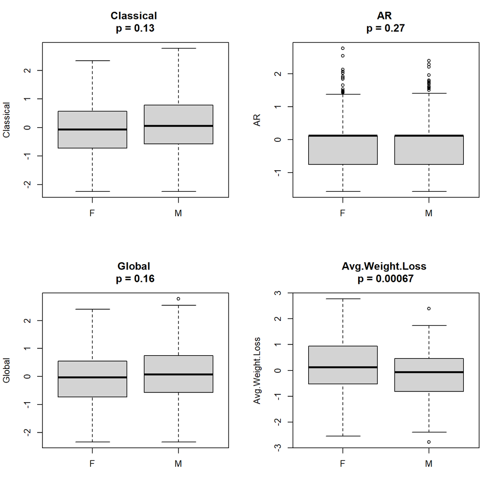

```r
#quartz(width = 8, height = 8)
par(mfrow = c(2,2))
for(i in 1:ncol(norm.cds)){
    if(exclude.zeros){
        nonzero.idx <- which(norm.cds[,i] != 0)
    }else{
        nonzero.idx <- 1:nrow(norm.cds)
    }
    model <- lm(norm.cds[nonzero.idx,i]~as.factor(factor.cds[nonzero.idx,"Sex"]))
    f <- summary(model)$fstatistic
    p <- pf(f[1],f[2],f[3],lower.tail=F)
    boxplot(norm.cds[nonzero.idx,i]~as.factor(factor.cds[nonzero.idx,"Sex"]),
        ylab = colnames(norm.cds)[i],
        main = paste(colnames(norm.cds)[i], "\np =", signif(p, 2)), xlab = "")
}
```

## CDS Trait Correlations

The following plot shows that global CDS is dominated by classical disease. It also shows that CDS in classical disease and AR are unrelated to each other. Lastly, it shows the correlations between the average weight loss and the CDS data.

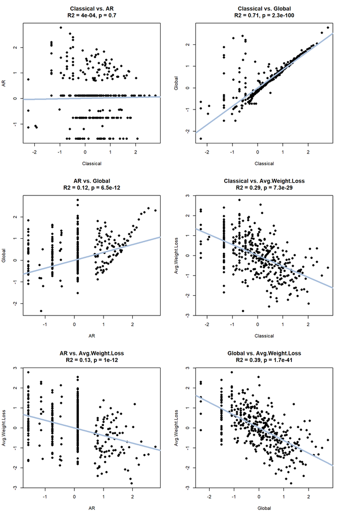

```r
trait.pairs <- pair.matrix(1:ncol(norm.cds))
par(mfrow = c(3,2))
for(i in 1:nrow(trait.pairs)){
    trait1 <- trait.pairs[i,1]
    trait2 <- trait.pairs[i,2]
    if(exclude.zeros){
        nonzero.idx <- intersect(which(norm.cds[,trait1] != 0), which(norm.cds[,trait2] != 0))
    }else{
        nonzero.idx <- 1:nrow(norm.cds)
    }
    plot.with.model(norm.cds[nonzero.idx,trait1], norm.cds[nonzero.idx,trait2],
        xlab = colnames(norm.cds)[trait1], ylab = colnames(norm.cds)[trait2],
        main = paste(colnames(norm.cds)[trait1], "vs.", colnames(norm.cds)[trait2]))
}
```

## Map CDS with Individuals

We mapped each CDS across the individual mice.

```r
if(add_founder_genotypes){
    methods.line <- "Both CC and founder strains were used for mapping."
}else{
    methods.line <- "We used only CC strains for mapping."
}

if(length(remove_strains) != 0){
    remove.line <- paste("We excluded the following strains:", paste(remove_strains, collapse = ", "))
}else{
    remove.line <- "No CC strains were excluded."
}
```

We used only CC strains for mapping. We excluded the following strains: CC027, NOD, 129

For the genoprobs and kinship matrices, we copied the entries for the individuals in each strain and used indices for row names.

The LOD traces for each trait are shown below along with plots for the FDR results. Significance thresholds from the permutations are also shown on the LOD traces.

```r
#remove any strains not used in mapping
mapping.strain.idx <- unlist(sapply(mapping.strains, function(x) grep(x, pheno.strains)))
pheno.strains <- pheno.strains[mapping.strain.idx]

#make a unique ID for each mouse that contains its strain and sex
u_id <- as.vector(apply(cds[mapping.strain.idx,c(1:2,5)], 1, function(x) paste(x, collapse = "_")))

K.idx <- sapply(mapping.strains, function(x) grep(x, rownames(mapping.K[[1]])))
K.num <- sapply(mapping.strains, function(x) length(which(pheno.strains == x)))
expanded.idx <- unlist(lapply(1:length(K.idx), function(x) rep(K.idx[x], K.num[x])))
groups <- names(expanded.idx)

exp.K <- lapply(1:length(mapping.K), function(x) mapping.K[[x]][expanded.idx,expanded.idx])
names(exp.K) <- names(mapping.K)

#create unique row and column names
for(i in 1:length(exp.K)){
    rownames(exp.K[[i]]) <- colnames(exp.K[[i]]) <- 1:length(u_id)
}

expanded.genoprobs <- mapping.genoprobs
for(i in 1:length(expanded.genoprobs)){
    expanded.genoprobs[[i]] <- mapping.genoprobs[[i]][expanded.idx,,]
    rownames(expanded.genoprobs[[i]]) <- 1:length(u_id)
}

#align the phenotypes with the strains
covar <- matrix(as.numeric(as.factor(cds[mapping.strain.idx,"Sex"])), ncol = 1)
rownames(covar) <- 1:length(u_id)

mapping.pheno <- norm.cds[mapping.strain.idx,]
rownames(mapping.pheno) <- 1:length(u_id)

mapping.factors <- factor.cds[mapping.strain.idx,]
mapping.covar <- matrix(as.numeric(as.factor(mapping.factors[,"Sex"])), ncol = 1)
rownames(mapping.covar) <- 1:length(u_id)
```

### Heritability

The heritability of CDS is shown below.

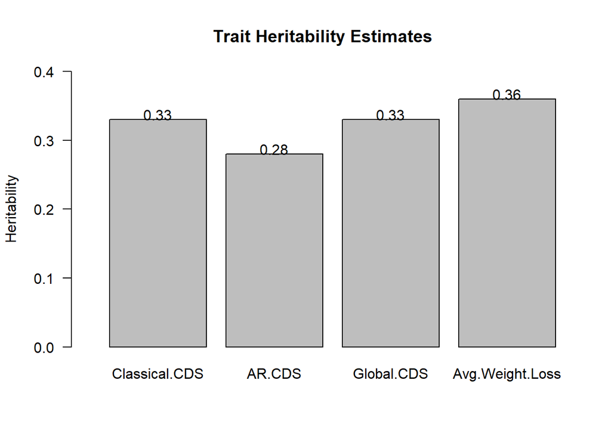

```r
overall.k.file <- here("Data", "kinship_overall.RDS")
if(!file.exists(overall.k.file) || overwrite_previous){
    overall.K <- calc_kinship(expanded.genoprobs, "overall")
    saveRDS(overall.K, overall.k.file)
}else{
    overall.K <- readRDS(overall.k.file)
}

ind.herit <- rep(NA, ncol(num.cds))
names(ind.herit) <- colnames(num.cds)
for(i in 1:ncol(num.cds)){
    nonzero.idx <- which(mapping.pheno[,i] != 0)
    ind.herit[i] <- est_herit(mapping.pheno[nonzero.idx,i,drop=FALSE], overall.K)
}

barplot_with_num(round(ind.herit, 2), ylab = "Heritability", xlab = "",
    ylim = c(0, 0.4), text.shift = 0.09, main = "Trait Heritability Estimates")
```

```r
#We have run into problems with extremely small variance
#in genotype probabilities leading to large LOD scores.
#round.digs attempts to solve this by rounding all
#genotype probabilities to the specified number of
#significant figures. All CC lines should be either 1 or
#0 at every locus, so 2 digits should be sufficient to
#get any errant heterozygotes, but also squash out very
#small variations
map_pheno <- function(map.geno, map.pheno, map.K, addcovar = NULL,
    intcovar = NULL, groups = NULL, exclude.zeros = TRUE,
    round.digs = 2,
    results.file = file.path(results.dir, "scan1_results.RDS")){

    if(!file.exists(results.file) || overwrite_previous){

        #round the genotypes so low-variance markers don't lead
        #to large QTL LOD scores
        rounded.geno <- map.geno
        for(chr in 1:length(rounded.geno)){
            rounded.geno[[chr]] <- round(map.geno[[chr]], round.digs)
        }

        pheno.scans <- vector(mode = "list", length = ncol(map.pheno))
        names(pheno.scans) <- colnames(map.pheno)
        for(ph in 1:ncol(map.pheno)){
            if(exclude.zeros){
                nonzero.idx <- which(map.pheno[,ph] != 0)
            }else{
                nonzero.idx <- 1:nrow(map.pheno)
            }

            pheno.scans[[ph]] <- scan1(rounded.geno, map.pheno[nonzero.idx,ph],
                addcovar = addcovar, intcovar = intcovar, kinship = map.K)
            #plot(pheno.scans[[ph]], map = map)
        }
        saveRDS(pheno.scans, results.file)
    }else{
        pheno.scans <- readRDS(results.file)
    }
    return(pheno.scans)
}


perm_scans <- function(map.geno, map.pheno, map.k, scan1.results,
    addcovar = NULL, intcovar = NULL, groups = NULL, nperm = nperm,
    max.exp.lod = 20, n.founders = 8, exclude.zeros = TRUE,
    results.file = file.path(results.dir, "perm.RDS"), round.digs = 2){

    #permutations for Matt's FDR method (see https://github.com/j-matthew-mahoney/cdf-fdrci.git)
    #right now this does one phenotype at a time, but we can change that later.
    perm.data <- vector(mode = "list", length = ncol(map.pheno))
    nind = nrow(map.pheno)
    #bin possible LOD scores
    breaks = lod2p(seq(max.exp.lod, 0, -0.01), nind = nind, k = n.founders)

    #round the genotypes to get rid of very small variances that
    #lead to large QTL LOD scores
    rounded.geno <- map.geno
    for(chr in 1:length(rounded.geno)){
        rounded.geno[[chr]] <- round(map.geno[[chr]], round.digs)
    }

    if(!file.exists(results.file)){
        for(ph in 1:ncol(map.pheno)){
            if(exclude.zeros){
                nonzero.idx <- which(map.pheno[,ph] != 0)
            }else{
                nonzero.idx <- 1:nrow(map.pheno)
            }
            if(!is.null(groups)){
                null_stats = scan1_groupperm_stats(rounded.geno,
                    pheno = map.pheno[nonzero.idx,ph,drop=FALSE],
                    groups = groups[nonzero.idx],
                    kinship = map.k, nperm = nperm, breaks = breaks,
                    addcovar = addcovar, intcovar = intcovar,
                    scan1_out = scan1.results[[ph]][,1,drop=FALSE], cores = cores)
            }else{
                null_stats = scan1perm_stats(rounded.geno,
                    pheno = map.pheno[nonzero.idx,ph,drop=FALSE],
                    kinship = map.k, nperm = nperm, breaks = breaks,
                    addcovar = addcovar, intcovar = intcovar,
                    scan1_out = scan1.results[[ph]][,1,drop=FALSE], cores = cores)
            }
            perm.data[[ph]] <- null_stats
        }
        saveRDS(perm.data, results.file)
    }else{
        perm.data <- readRDS(results.file)
    }
    return(perm.data)
}

#plots LOD traces with significance thresholds and returns a matrix
#with traits in rows and the different significance thresholds for
#LOD scores in columns corresponding to both standard and FDR-adjusted
#LOD scores.
plot_fdr_fun <- function(scan.results, perm.results, tab.level = "###", maxy = NULL){

    fdr_summaries <- matrix(NA, nrow = length(scan.results), ncol = 5)
    rownames(fdr_summaries) <- names(scan.results)
    for(ph in 1:length(scan.results)){
        cat(tab.level, names(scan.results)[ph], "\n")
        summary_thresholds = fdr_summarize(null_stats = perm.results[[ph]],
            fdr_cl = 0.95, geno_sig = alpha, fdr_thresh = c(0.1, 0.2, 0.4),
            plot = FALSE, quartz = FALSE)

        finite.thresh <- which(is.finite(summary_thresholds))

        if(is.null(maxy)){
            maxy <- max(c(scan.results[[ph]][,1],
                summary_thresholds[finite.thresh], na.rm = TRUE))*1.1
        }
        par(mar = c(4, 4, 4, 2))
        plot(scan.results[[ph]], map = map, main = names(scan.results)[ph],
            ylim = c(0, maxy))
        abline(h = summary_thresholds, lty = 1:length(summary_thresholds))
        plot.dim <- par("usr")
        par(xpd = TRUE)
        #text(x = plot.dim[2], y = summary_thresholds[finite.thresh],
        #    labels = names(summary_thresholds)[finite.thresh], cex = 0.5, adj = 0)
        text(x = plot.dim[2]*1.01, y = summary_thresholds[finite.thresh],
            labels = alpha, cex = 0.5, adj = 0)

        #text(x = plot.dim[1], y = summary_thresholds[finite.thresh],
        #    labels = summary_thresholds[finite.thresh], cex = 0.7, adj = 1)
        par(xpd = FALSE)
        fdr_summaries[ph,] <- summary_thresholds
        cat("\n\n")
    }
    colnames(fdr_summaries) <- names(summary_thresholds)
    invisible(fdr_summaries)
}

#This function is similar to above, but uses permutation results
#from qtl2's scan1perm, rather than the fdr scan.
plot_pval_fun <- function(scan.results, perm.results, tab.level = "###"){

    sig_summaries <- t(summary(perm.results, alpha = alpha))
    finite.thresh <- which(is.finite(sig_summaries))
    #fdr_summaries <- matrix(NA, nrow = length(scan.results), ncol = length(alpha))
    #rownames(fdr_summaries) <- names(scan.results)
    #colnames(fdr_summaries) <- paste0("FDR ", alpha*100, "%")

    for(ph in 1:length(scan.results)){
        cat(tab.level, names(scan.results)[ph], "\n")

        trait.p <- lod2p(scan.results[[ph]][,1], nind = attr(scan.results[[ph]], "sample_size"), k = 8)
        trait.fdr <- p.adjust(trait.p, "fdr")
        #plot(scan.results[[ph]][,1], trait.fdr, ylim = c(0,1))
        #abline(h = alpha)

        fdr.idx <- lapply(alpha, function(x) which(round(trait.fdr, 2) == x))
        fdr.thresh <- unlist(lapply(fdr.idx, function(x) if(length(x) > 0){scan.results[[ph]][x]}else{NA}))
        #fdr_summaries[ph,] <- fdr.thresh

        maxy <- max(c(scan.results[[ph]][,1],
            sig_summaries[ph,], na.rm = TRUE))*1.1
        par(mar = c(4, 4, 4, 8))
        plot(scan.results[[ph]], map = map, main = names(scan.results)[ph],
            ylim = c(0, maxy))
        abline(h = sig_summaries[ph,], lty = c(1,2))
        #abline(h = fdr_summaries[ph,])
        plot.dim <- par("usr")
        par(xpd = TRUE)
        text(x = plot.dim[2]*1.005, y = sig_summaries[ph,],
            labels = colnames(sig_summaries), cex = 0.7, adj = 0)
        par(xpd = FALSE)
        cat("\n\n")
    }
    #sig_summaries <- cbind(sig_summaries, fdr_summaries)
    sig_summaries <- cbind(sig_summaries)
    invisible(sig_summaries)
}

select_threshold <- function(scan.results, fdr_summaries){
    for(ph in 1:length(scan.results)){
        finite.thresh <- fdr_summaries[ph,which(is.finite(fdr_summaries[ph,]))]
        peak.tables <- lapply()
    }
}

allele_coef <- function(map.geno, map.pheno, map.k, addcovar = NULL,
    intcovar = NULL, scan.results, lod.threshold, exclude.zeros,
    chr.lod.file, chr.coef.file, round.digs = 2){

    peak.table <- lapply(1:length(scan.results),
        function(x) find_peaks(scan.results[[x]], map = map,
        threshold = lod.threshold[x]))

    #round genotypes to reduce risk of low-variance alleles
    #leading to large QTL LOD scores
    rounded.geno <- map.geno
    for(chr in 1:length(rounded.geno)){
        rounded.geno[[chr]] <- round(map.geno[[chr]], round.digs)
    }

    if(!file.exists(chr.lod.file) || overwrite_previous){
        chr.lod <- chr.coef <- vector(mode = "list", length = nrow(Reduce("rbind", peak.table)))
        idx = 1
        for(ph in 1:length(peak.table)){
            if(nrow(peak.table[[ph]]) != 0){
                for(p in 1:nrow(peak.table[[ph]])){
                    chr <- peak.table[[ph]][p,"chr"]
                    peak.loc <- peak.table[[ph]][p,"pos"]
                    trait = names(scan.results)[ph]
                    chr.locale <- which(names(map.geno) == chr)

                    if(exclude.zeros){
                        nonzero.idx <- which(map.pheno[,ph] != 0)
                    }else{
                        nonzero.idx <- 1:nrow(map.pheno)
                    }

                    chr.scan <- scan1(rounded.geno[,chr],
                        map.pheno[nonzero.idx,ph,drop=FALSE],
                        kinship = map.k[[chr.locale]], addcovar = addcovar,
                        intcovar = intcovar)
                    chr.lod[[idx]] <- chr.scan
                    #plot(chr.scan, map = map);abline(v = peak.loc)

                    effects.scan <- scan1blup(rounded.geno[,chr],
                        map.pheno[nonzero.idx,ph,drop=FALSE],
                        kinship = map.k[[chr.locale]], addcovar = addcovar)
                    chr.coef[[idx]] <- effects.scan
                    #plot_coefCC(effects.scan, map = map);abline(v = peak.loc)
                    idx = idx + 1 #increment regardless of whether there is a peak here
                }

            }
        }
        saveRDS(chr.lod, chr.lod.file)
        saveRDS(chr.coef, chr.coef.file)
    }else{
        chr.lod <- readRDS(chr.lod.file)
        chr.coef <- readRDS(chr.coef.file)
    }
    result <- list("peak.table" = peak.table, "LOD" = chr.lod, "Coef" = chr.coef)
    return(result)
}

plot_coef_scans <- function(coef.results, map.geno, map.pheno, fdr_results = NULL,
    tab.level = "###", sig_lines = c("Genome-wide", "FDR")){

    if(!is.null(fdr_results)){
        sig_lines = sig_lines[1]
        line.idx <- grep(sig_lines, colnames(fdr_results))
    }

    peak.table <- coef.results$peak.table
    chr.lod <- coef.results$LOD
    chr.coef <- coef.results$Coef

    idx <- 1
    for(ph in 1:length(peak.table)){
        if(nrow(peak.table[[ph]]) != 0){
            for(p in 1:nrow(peak.table[[ph]])){
                par(mfrow = c(2,1))
                chr <- peak.table[[ph]][p,"chr"]
                trait <- colnames(map.pheno)[ph]
                peak.loc <- peak.table[[ph]][p,"pos"]
                chr.locale <- which(names(map.geno) == chr)

                cat(tab.level, trait, "Chr", chr, "\n")

                if(!is.null(fdr_results)){
                    ymax <- max(c(chr.lod[[idx]], fdr_results[ph,line.idx]))
                }else{
                    ymax <- max(chr.lod[[idx]])
                }
                plot(chr.lod[[idx]], map = map, main = paste(trait, "Chr", chr),
                    ylim = c(0, ymax*1.05))
                if(!is.null(fdr_results)){
                    abline(h = fdr_results[ph,line.idx], lty = ph)

                    plot.dim <- par("usr")
                    par(xpd = TRUE)
                    text(x = plot.dim[2], y = fdr_results[ph,line.idx],
                        labels = gsub(paste0(sig_lines, " "), "", colnames(fdr_results)[line.idx]),
                        cex = 0.5, adj = 0)
                }
                par(xpd = FALSE)

                plot_coefCC(chr.coef[[idx]], map = map, main = paste(trait, "Chr", chr),
                    col = strain.colors)
                abline(v = peak.loc, lwd = 2)

                idx = idx + 1
                cat("\n\n")
            }
        }
    }
}
```

```r
cds.scans <- map_pheno(expanded.genoprobs, mapping.pheno, exp.K,
    addcovar = covar, exclude.zeros = exclude.zeros,results.file = file.path(results.dir, "scan1_results_cds.RDS"))



if(run_permutations){
    #perm_strata <- names(expanded.idx)
    #names(perm_strata) <- rownames(mapping.pheno)
    #cds.perm <- scan1perm(expanded.genoprobs, mapping.pheno, kinship = exp.K,
    #    addcovar = covar, perm_strata = perm_strata, n_perm = nperm, cores = detectCores()-1)

    #cds.perm <- scan1perm(expanded.genoprobs, mapping.pheno, kinship = exp.K,
    #    addcovar = covar, n_perm = nperm, cores = detectCores()-1)

    cds.perm <- perm_scans(expanded.genoprobs, mapping.pheno, exp.K,
        cds.scans, addcovar = covar, groups = names(expanded.idx),
        exclude.zeros = exclude.zeros, nperm = nperm,
        results.file = file.path(results.dir, "scan1perm_results_cds_perm_scans.RDS"))
}
```

```r
nperm = 1000
f.idx <- which(covar[,1] == 1)
m.idx <- which(covar[,1] == 2)

strain.strata <- names(expanded.idx)
names(strain.strata) <- rownames(mapping.pheno)

cds.f.scans <- map_pheno(expanded.genoprobs, mapping.pheno[f.idx,], exp.K,
    exclude.zeros = exclude.zeros,
    results.file = file.path(results.dir, "scan1_results_cds_f.RDS"))

cds.f.perm.results.file <- file.path(results.dir, "scan1perm_results_cds_f.RDS")
if(!file.exists(cds.f.perm.results.file)){
    cds.f.perm <- scan1perm(genoprobs = expanded.genoprobs,
        pheno = mapping.pheno[f.idx,,drop=FALSE], addcovar = covar,
        n_perm = nperm, cores = 4)
    saveRDS(cds.f.perm, cds.f.perm.results.file)
}else{
    cds.f.perm <- readRDS(cds.f.perm.results.file)
}

cds.m.scans <- map_pheno(expanded.genoprobs, mapping.pheno[m.idx,], exp.K,
    exclude.zeros = exclude.zeros,
    results.file = file.path(results.dir, "scan1_results_cds_m.RDS"))

cds.m.perm.results.file <- file.path(results.dir, "scan1perm_results_cds_m.RDS")
if(!file.exists(cds.m.perm.results.file)){
    cds.m.perm <- scan1perm(genoprobs = expanded.genoprobs,
        pheno = mapping.pheno[m.idx,,drop=FALSE], addcovar = covar,
        n_perm = nperm, cores = 4)
    saveRDS(cds.m.perm, cds.m.perm.results.file)
}else{
    cds.m.perm <- readRDS(cds.m.perm.results.file)
}

cds.add.scans <- map_pheno(expanded.genoprobs, mapping.pheno, exp.K,
    exclude.zeros = exclude.zeros, addcovar = covar,
    results.file = file.path(results.dir, "scan1_results_cds_add.RDS"))

cds.add.perm.results.file <- file.path(results.dir, "scan1perm_results_cds_add.RDS")
if(!file.exists(cds.add.perm.results.file)){
    cds.add.perm <- scan1perm(genoprobs = expanded.genoprobs,
        pheno = mapping.pheno, addcovar = covar,
        n_perm = nperm, cores = 4)
    saveRDS(cds.add.perm, cds.add.perm.results.file)
}else{
    cds.add.perm <- readRDS(cds.add.perm.results.file)
}

cds.int.scans <- map_pheno(expanded.genoprobs, mapping.pheno, exp.K,
    exclude.zeros = exclude.zeros, addcovar = covar, intcovar = covar,
    results.file = file.path(results.dir, "scan1_results_cds_int.RDS"))

cds.int.perm.results.file <- file.path(results.dir, "scan1perm_results_cds_int.RDS")
if(!file.exists(cds.int.perm.results.file)){
    cds.int.perm <- scan1perm(genoprobs = expanded.genoprobs,
        pheno = mapping.pheno, addcovar = covar, intcovar = covar,
        n_perm = nperm, cores = 4)
    saveRDS(cds.int.perm, cds.int.perm.results.file)
}else{
    cds.int.perm <- readRDS(cds.int.perm.results.file)
}
```

### CDS QTL for Females

```r
#pdf("~/Desktop/CDS_Female.pdf", width = 10, height = 12);par(mfrow = c(3,1))
plot_pval_fun(scan.results = cds.f.scans, perm.results = cds.f.perm, tab.level = "####")
```

#### Classical

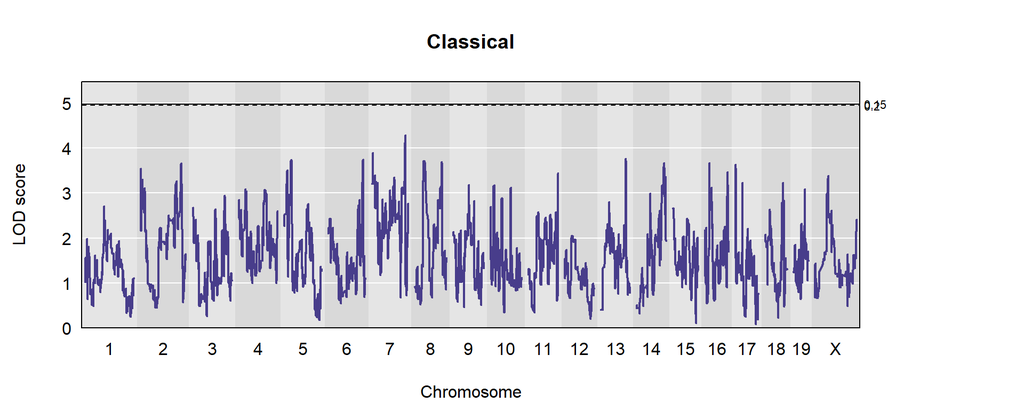

#### AR

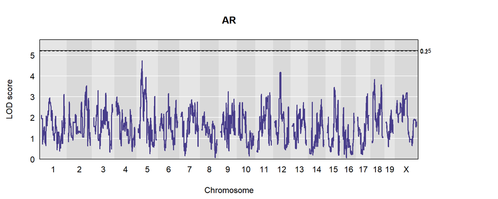

#### Global

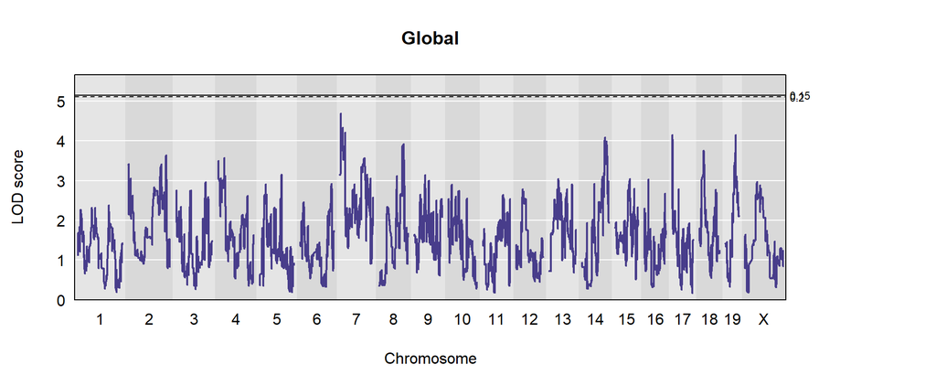

#### Avg.Weight.Loss

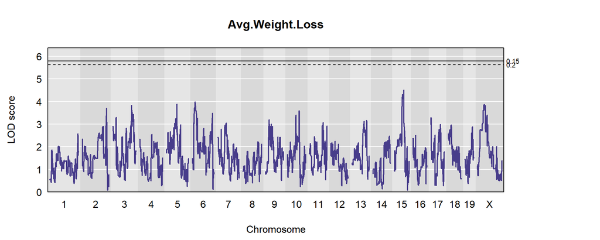

```r
#dev.off()
```

### CDS QTL for Males

```r
#pdf("~/Desktop/CDS_Male.pdf", width = 10, height = 12);par(mfrow = c(3,1))
plot_pval_fun(scan.results = cds.m.scans, perm.results = cds.m.perm, tab.level = "####")
```

#### Classical

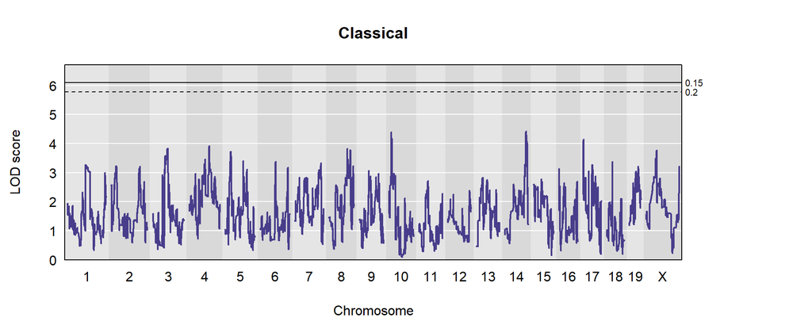

#### AR

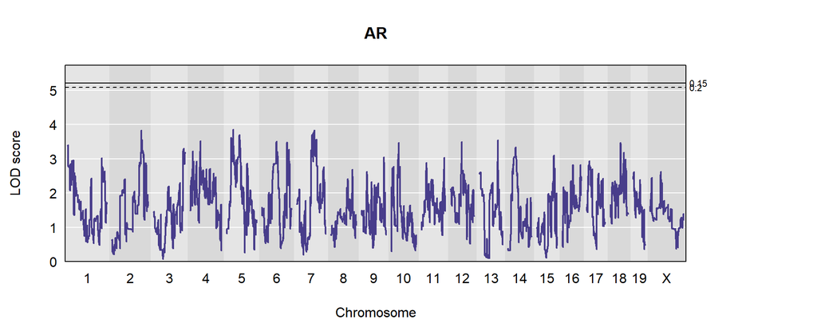

#### Global

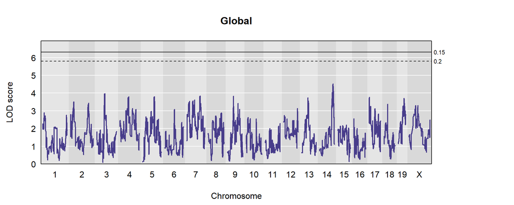

#### Avg.Weight.Loss

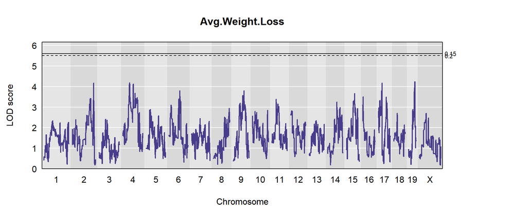

```r
#dev.off()
```

### CDS QTL for Both Sexes Overlayed

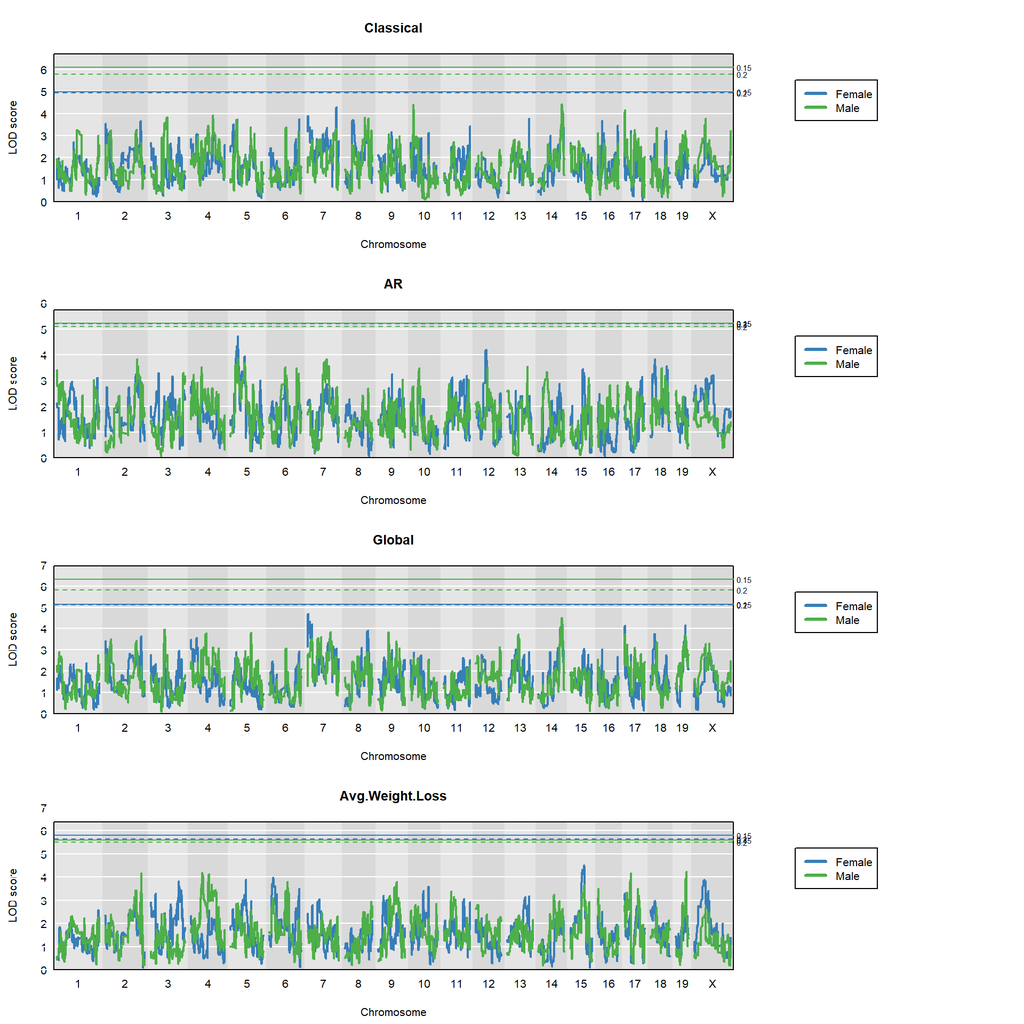

```r
#pdf("~/Desktop/CDS_Sex_Overlayed.pdf", width = 12, height = 12)
layout.mat <- matrix(c(1:8), ncol = 2, byrow = TRUE)
layout(layout.mat, widths = c(1, 0.3))
sex.cols = c("Female" = "#377eb8", "Male" = "#4daf4a")
for(i in 1:length(cds.f.scans)){
    par(mar = c(4,4,4,4))

    sig.level.f <- summary(cds.f.perm, alpha = alpha)[,i]
    sig.level.m <- summary(cds.m.perm, alpha = alpha)[,i]
    ymax <- max(c(sig.level.f, sig.level.m, cds.f.scans[[i]]))*1.1
    plot(cds.f.scans[[i]], map = map, ylim = c(0,ymax), col = sex.cols["Female"],
        main = names(cds.f.scans)[i])
    plot(cds.m.scans[[i]], map = map, add = TRUE, col = sex.cols["Male"])
    plot.dim <- par("usr")
    segments(x0 = plot.dim[1], x1 = plot.dim[2], y0 = sig.level.f, lty = c(1,2),
        col = sex.cols["Female"])
    segments(x0 = plot.dim[1], x1 = plot.dim[2], y0 = sig.level.m, lty = c(1,2),
        col = sex.cols["Male"])
    par(xpd = NA)
    text(x = rep(plot.dim[2]*1.005, 2), y = sig.level.f, labels = alpha, adj = 0, cex = 0.7)
    text(x = rep(plot.dim[2]*1.005, 2), y = sig.level.m, labels = alpha, adj = 0, cex = 0.7)

    par(mar = c(0,0,4,2))
    plot.new()
    plot.window(xlim = c(0,1), ylim = c(0,1))
    legend(0, 0.9, lty = 1, col = sex.cols, legend = names(sex.cols), lwd = 3)
}
```

```r
#dev.off()
```

### CDS QTL for Interaction Overlayed

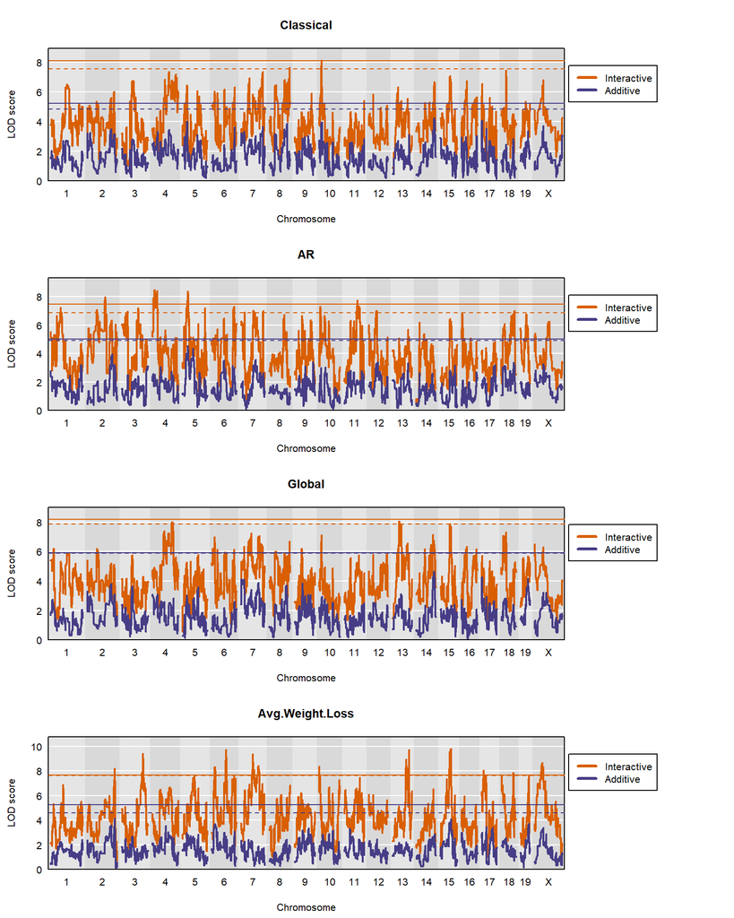

```r
#pdf("~/Desktop/CDS_Interaction_overlayed.pdf", width = 12, height = 12)
layout(matrix(c(1:8), ncol = 2, byrow = TRUE), widths = c(1, 0.3))
for(i in 1:length(cds.int.scans)){
    par(mar = c(4,4,4,0))
    sig.level.int <- summary(cds.int.perm, alpha = alpha)[,i]
    sig.level.add <- summary(cds.add.perm, alpha = alpha)[,i]
    ymax <- max(c(sig.level.int, sig.level.add, cds.int.scans[[i]], cds.add.scans[[i]]))*1.1
    plot(cds.int.scans[[i]], map = map, ylim = c(0, ymax), main = names(cds.int.scans)[i],
        col = "#d95f02")
    plot(cds.add.scans[[i]], map = map, add = TRUE, col = "#463D86")
    abline(h = sig.level.int, lty = c(1,2), col = "#d95f02")
    abline(h = sig.level.add, lty = c(1,2), col = "#463D86")
    par(mar = c(4,0,4,4))
    plot.new()
    plot.window(xlim = c(0,1), ylim = c(0,1))
    legend(0, 0.9, lty = 1, col = c("#d95f02", "#463D86"),
        legend = c("Interactive", "Additive"), lwd = 3)
}
```

```r
#dev.off()
```

### CDS QTL Interaction-Additive

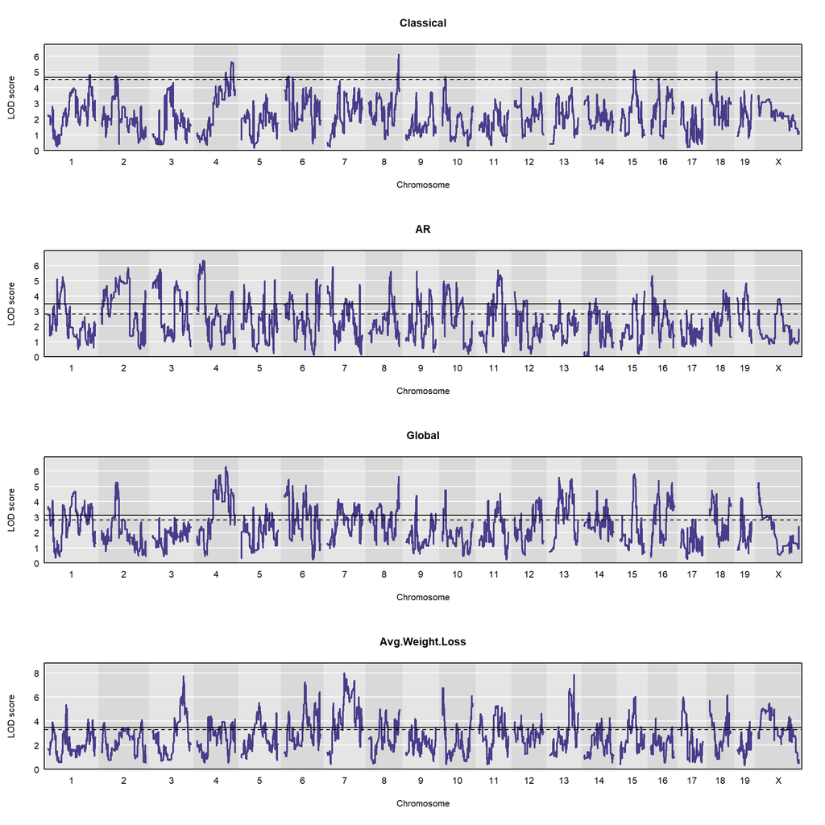

```r
#pdf("~/Desktop/CDS_Interaction-Additive.pdf", width = 10, height = 12)
par(mfrow = c(4,1))
for(i in 1:length(cds.int.scans)){
    sig.level.int <- summary(cds.int.perm-cds.add.perm, alpha = alpha)[,i]
    ymax <- max(c(sig.level.int, cds.int.scans[[i]]-cds.add.scans[[i]]))*1.1
    plot(cds.int.scans[[i]]-cds.add.scans[[i]], map = map, ylim = c(0, ymax),
        main = names(cds.int.scans)[i])
    abline(h = sig.level.int, lty = c(1,2))
}
```

```r
#dev.off()
```

### CDS by individual LOD traces

```r
#plot the scans, and FDR results
if(run_permutations){
    #pdf("~/Desktop/test.pdf")
    fdr_summaries_cds <- plot_fdr_fun(scan.results = cds.scans, perm.results = cds.perm,
        tab.level = "####", maxy = NULL)
    #sig_summaries_cds <- plot_pval_fun(scan.results = cds.scans, perm.results = cds.perm, tab.level = "####")
    #dev.off()
}else{
    for(i in 1:length(cds.scans)){
        cat("####", names(cds.scans)[i], "\n")
        plot(cds.scans[[i]], map = map)
        cat("\n\n")
    }
}
```

#### Classical

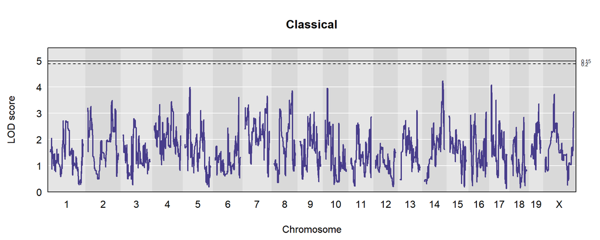

#### AR

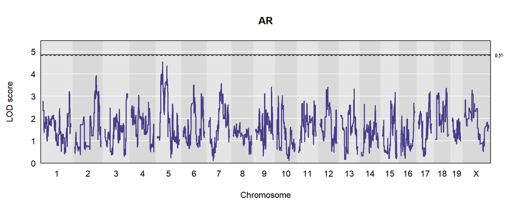

#### Global

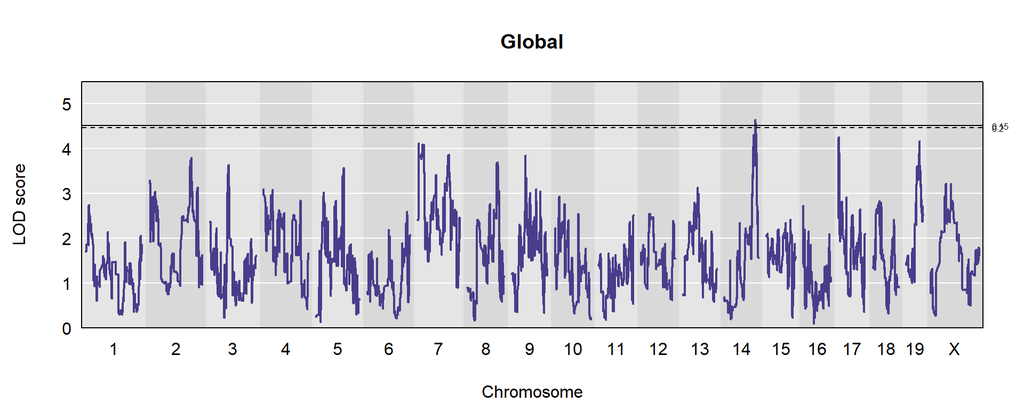

#### Avg.Weight.Loss

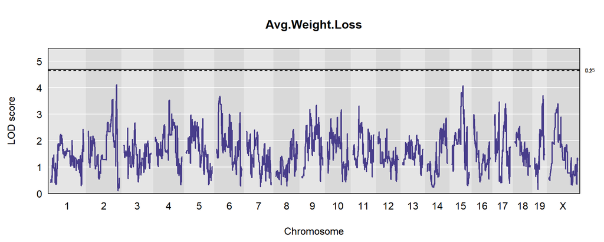

### CDS by individual allele effects

The following plot shows the allele effects for the Chr 14 QTL for Global CDS. The full chromosome has a lot of allele frequency weirdness on it. There are two plots below. One of the full chromosome, and another that captures as much of the QTL as possible without showing the weirdness.

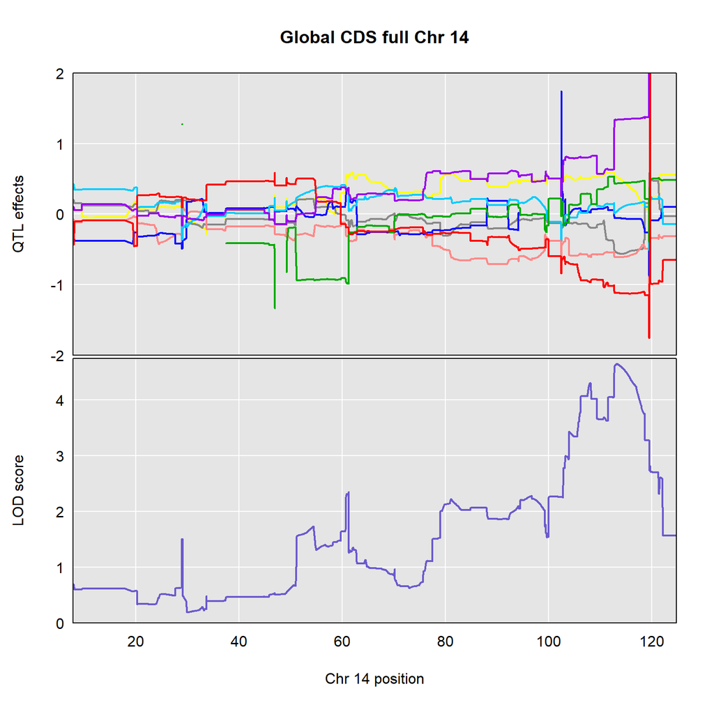

```r
#round genotypes to squash out the wild associations we
#get with teeny tiny probabilities
rounded.geno <- expanded.genoprobs
for(i in 1:length(rounded.geno)){
    rounded.geno[[i]] <- round(rounded.geno[[i]], 2)
}

chr = 14
global.lod <- scan1(rounded.geno[,chr], mapping.pheno[,"Global"], exp.K[[chr]],
    addcovar = covar)
global.coef <- scan1coef(rounded.geno[,chr], mapping.pheno[,"Global"], exp.K[[chr]],
    addcovar = covar)

plot_coefCC(global.coef, map = map, scan1_output = global.lod,
    ylim = c(-2, 2), col = strain.colors, main = "Global CDS full Chr 14",
    top_panel_prop = 0.5)
```

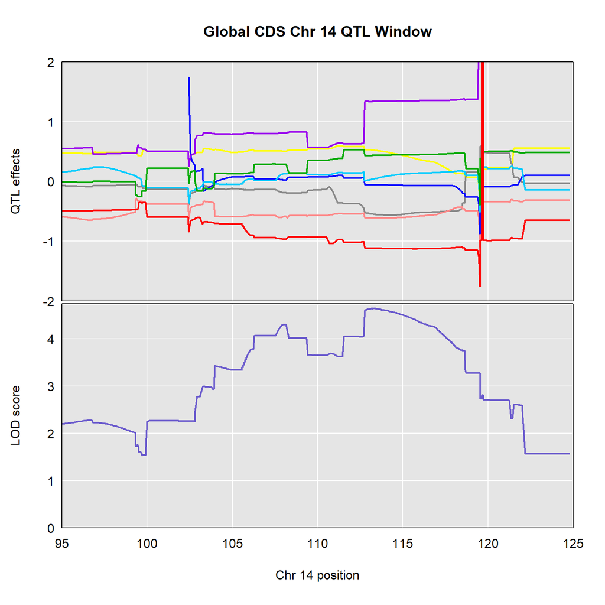

```r
plot_coefCC(global.coef, map = map, scan1_output = global.lod,
    ylim = c(-2, 2), col = strain.colors, xlim = c(95, 125),
    main = "Global CDS Chr 14 QTL Window", top_panel_prop = 0.5)
```

### Average Weight Loss by individual allele effects

The following plot shows the allele effects for the Chr 2 QTL for Average Weight Loss. The methods for plotting this chromosome and phenotype are the same as above, including the two separate plots with x-limit perimeters modified as appropriate.

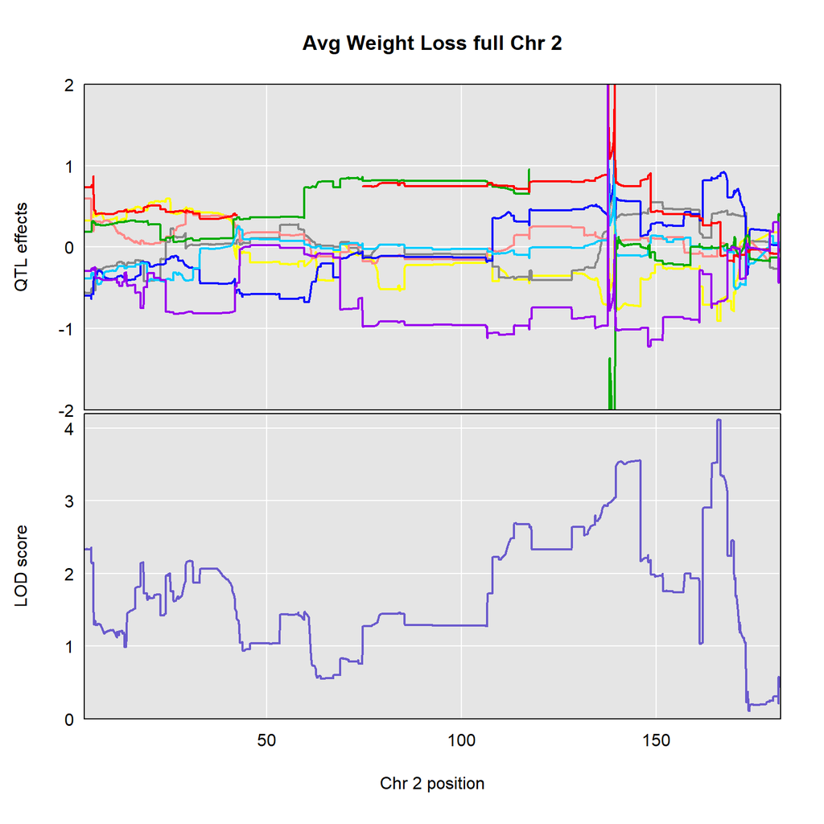

```r
#round genotypes to squash out the wild associations we
#get with teeny tiny probabilities
rounded.geno <- expanded.genoprobs
for(i in 1:length(rounded.geno)){
    rounded.geno[[i]] <- round(rounded.geno[[i]], 2)
}

chr = 2
av_weight_loss.lod <- scan1(rounded.geno[,chr], mapping.pheno[,"Avg.Weight.Loss"], exp.K[[chr]],
    addcovar = covar)
av_weight_loss.coef <- scan1coef(rounded.geno[,chr], mapping.pheno[,"Avg.Weight.Loss"], exp.K[[chr]],
    addcovar = covar)

plot_coefCC(av_weight_loss.coef, map = map, scan1_output = av_weight_loss.lod,
    ylim = c(-2, 2), col = strain.colors, main = "Avg Weight Loss full Chr 2",
    top_panel_prop = 0.5)
```

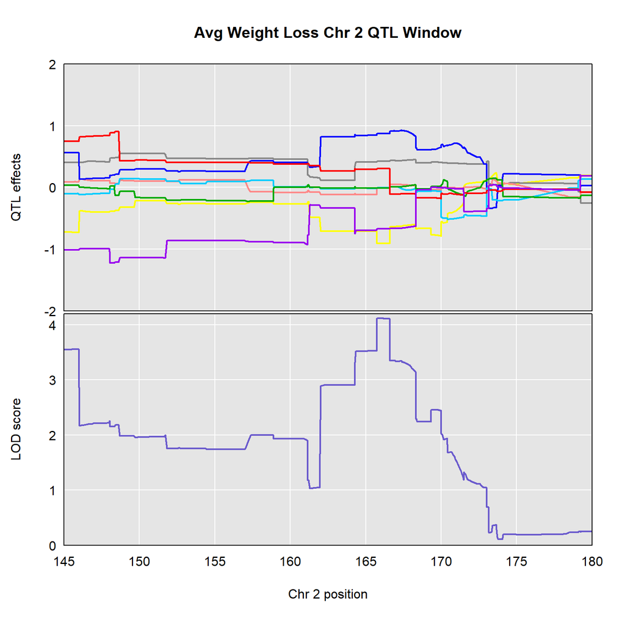

```r
plot_coefCC(av_weight_loss.coef, map = map, scan1_output = av_weight_loss.lod,
    ylim = c(-2, 2), col = strain.colors, xlim = c(145, 180),
    main = "Avg Weight Loss Chr 2 QTL Window", top_panel_prop = 0.5)
```

```r
cds.coef <- allele_coef(map.geno = expanded.genoprobs,
    map.pheno = mapping.pheno, map.k = exp.K, addcovar = mapping.covar,
    scan.results = cds.scans,
    lod.threshold = allele.thresh, exclude.zeros = exclude.zeros,
    chr.lod.file = file.path(results.dir, "Chr.LOD.cds.RDS"),
    chr.coef.file = file.path(results.dir, "Chr.Coef.cds.RDS"))

#pdf("~/Desktop/test.pdf", width = 7, height = 7)
if(run_permutations){
    plot_coef_scans(coef.results = cds.coef,
        map.geno = expanded.genoprobs, map.pheno = mapping.pheno,
        fdr_results = fdr_summaries_cds, tab.level = "####",
        sig_lines = "Genome-wide")
}else{
    plot_coef_scans(coef.results = cds.coef,
        map.geno = expanded.genoprobs, map.pheno = mapping.pheno,
        fdr_results = NULL, tab.level = "####",
        sig_lines = "Genome-wide")
}

#dev.off()
```

### LOD intervals

The following tables show LOD peak intervals for the top 3 peaks from each trait.

```r
top.n <- 3
for(ph in 1:length(cds.scans)){
    cat("####", names(cds.scans)[ph], "\n")
    peak.table <- find_peaks(cds.scans[[ph]], map = map, prob = 0.95)
    lod.order <- order(peak.table[,"lod"], decreasing = TRUE)
    top.peaks <- peak.table[lod.order[1:top.n],3:ncol(peak.table)]
    rownames(top.peaks) <- NULL
    print(kable(top.peaks))
    cat("Thresholds:\n")
    print(kable(fdr_summaries_cds[ph,,drop=FALSE]))
    cat("\n\n")
}
```

#### Classical

| chr | pos | lod | ci_lo | ci_hi |
| --- | --- | --- | --- | --- |
| 14 | 114.770789 | 4.229915 | 61.291464 | 121.99659 |
| 17 | 5.134843 | 4.071887 | 3.338879 | 77.24066 |
| 5 | 31.137460 | 3.991868 | 13.262558 | 116.10656 |

Thresholds:

|  | Genome-wide sig. 15% | Genome-wide sig. 20% | FDR 10% | FDR 20% | FDR 40% |
| --- | --- | --- | --- | --- | --- |
| Classical | 4.99 | 4.88 | Inf | Inf | Inf |

#### AR

| chr | pos | lod | ci_lo | ci_hi |
| --- | --- | --- | --- | --- |
| 5 | 36.73154 | 4.532691 | 24.70172 | 73.36274 |
| 2 | 150.73921 | 3.932619 | 109.66555 | 173.12903 |
| 7 | 91.15838 | 3.571353 | 10.13527 | 140.75611 |

Thresholds:

|  | Genome-wide sig. 15% | Genome-wide sig. 20% | FDR 10% | FDR 20% | FDR 40% |
| --- | --- | --- | --- | --- | --- |
| AR | 4.86 | 4.82 | Inf | Inf | Inf |

#### Global

| chr | pos | lod | ci_lo | ci_hi |
| --- | --- | --- | --- | --- |
| 14 | 113.217915 | 4.648191 | 103.968671 | 118.63119 |
| 17 | 5.134843 | 4.255722 | 3.338879 | 94.82649 |
| 19 | 48.284023 | 4.163150 | 36.138906 | 60.04183 |

Thresholds:

|  | Genome-wide sig. 15% | Genome-wide sig. 20% | FDR 10% | FDR 20% | FDR 40% |
| --- | --- | --- | --- | --- | --- |
| Global | 4.51 | 4.46 | Inf | Inf | Inf |

#### Avg.Weight.Loss

| chr | pos | lod | ci_lo | ci_hi |
| --- | --- | --- | --- | --- |
| 2 | 165.74960 | 4.113297 | 3.182308 | 170.11771 |
| 15 | 67.14769 | 4.072448 | 22.725310 | 90.92081 |
| 19 | 51.96530 | 3.702635 | 33.000615 | 58.25000 |

Thresholds:

|  | Genome-wide sig. 15% | Genome-wide sig. 20% | FDR 10% | FDR 20% | FDR 40% |
| --- | --- | --- | --- | --- | --- |
| Avg.Weight.Loss | 4.69 | 4.65 | Inf | Inf | Inf |